# Crear diagramas de Barras (Bar Charts) en el lenguaje de programación R

Utilizando la función base barplot() y los paquetes ggplot2 y lattice.

Renzo Cáceres Rossi

Andrés Cáceres Rossi

Vincenzo Cáceres Larkson

26-09-2022

**Fin Documento**

## Diagramas de Barras

El diagrama de barras (**Bar Chart**) es un gráfico estadístico que nos permite representar la distribución de frecuencias de variables cualitativas y cuantitativas discretas; nuestro objetivo es pasar del lápiz y papel al uso de los lenguajes de programación R version 4.2.1 (2022-06-23 ucrt)(R Core Team, 2022) y Python 3.9.7(Van Rossum & Drake Jr, 1995) , así como el paquete **RMarkdown**[^1], recomendamos la lectura del libro **El Arte de Programar en R**(Santana Sepúlveda et al., 2014); compartimos la siguiente imagen como referencia.

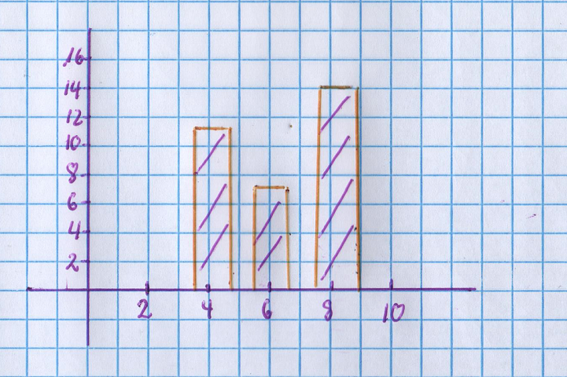

## 0.1 Data Set - mtcars

**mtcars** es un data set que ya viene precargado al momento de instalar el **lenguaje de programación R** en nuestro sistema, haremos uso de dicho data set para la creación de distintos diagramas de barras, de las 11 variables y 32 observaciones que lo componen nos enfocaremos en las variables **cyl** (cilindro) y **gear** (engranajes) como se muestra a continuación.

### 0.1.1 mtcars

```r
summary(mtcars)
```

```
##       mpg             cyl             disp             hp
##  Min.   :10.40   Min.   :4.000   Min.   : 71.1   Min.   : 52.0
##  1st Qu.:15.43   1st Qu.:4.000   1st Qu.:120.8   1st Qu.: 96.5
##  Median :19.20   Median :6.000   Median :196.3   Median :123.0
##  Mean   :20.09   Mean   :6.188   Mean   :230.7   Mean   :146.7
##  3rd Qu.:22.80   3rd Qu.:8.000   3rd Qu.:326.0   3rd Qu.:180.0
##  Max.   :33.90   Max.   :8.000   Max.   :472.0   Max.   :335.0
##       drat             wt             qsec             vs
##  Min.   :2.760   Min.   :1.513   Min.   :14.50   Min.   :0.0000
##  1st Qu.:3.080   1st Qu.:2.581   1st Qu.:16.89   1st Qu.:0.0000
##  Median :3.695   Median :3.325   Median :17.71   Median :0.0000
##  Mean   :3.597   Mean   :3.217   Mean   :17.85   Mean   :0.4375
##  3rd Qu.:3.920   3rd Qu.:3.610   3rd Qu.:18.90   3rd Qu.:1.0000
##  Max.   :4.930   Max.   :5.424   Max.   :22.90   Max.   :1.0000
##        am              gear            carb
##  Min.   :0.0000   Min.   :3.000   Min.   :1.000
##  1st Qu.:0.0000   1st Qu.:3.000   1st Qu.:2.000
##  Median :0.0000   Median :4.000   Median :2.000
##  Mean   :0.4062   Mean   :3.688   Mean   :2.812
##  3rd Qu.:1.0000   3rd Qu.:4.000   3rd Qu.:4.000
##  Max.   :1.0000   Max.   :5.000   Max.   :8.000
```

### 0.1.2 var_cyl

```r
summary(mtcars$cyl)
```

```
##    Min. 1st Qu.  Median    Mean 3rd Qu.    Max.
##   4.000   4.000   6.000   6.188   8.000   8.000
```

### 0.1.3 var_gear

```r
summary(mtcars$gear)
```

```
##    Min. 1st Qu.  Median    Mean 3rd Qu.    Max.
##   3.000   3.000   4.000   3.688   4.000   5.000
```

### 0.1.4 var_carb

```r
summary(mtcars$carb)
```

```
##    Min. 1st Qu.  Median    Mean 3rd Qu.    Max.
##   1.000   2.000   2.000   2.812   4.000   8.000
```

## 0.2 Bar Chart - barplot()

La función `barplot()` nos permite crear diagramas de barras (**Bar Charts**) en el lenguaje de programación R, utilizaremos la variable cyl (**cilindros**) para crear el gráfico estadístico respectivo, como se muestra en la siguiente imagen.

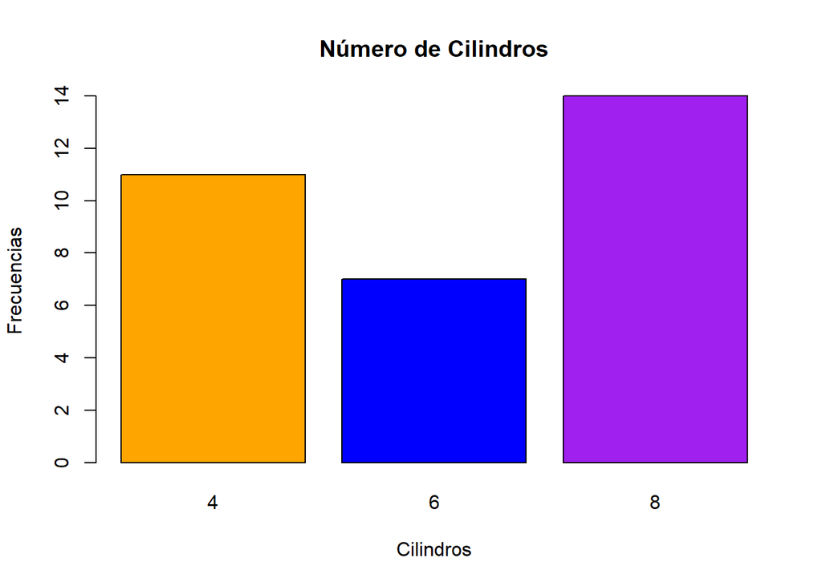

Bar Chart creado con la función barplot()

```r
x <- table(mtcars$cyl)

colores <- c("orange","blue","purple")

barplot(x,xlab="Cilindros",ylab="Frecuencias",main="Número de Cilindros",col=colores)
```

## 0.3 Bar Chart - ggplot2

**ggplot2**(Wickham, 2016) es un paquete del lenguaje de programación que nos permite crear gráficos estadísticos de gran calidad, haremos uso de la variable cyl (**cilindros**) para la creación del gráfico estadístico respectivo, como se muestra a continuación.

**Mostrar/Ocultar Código**

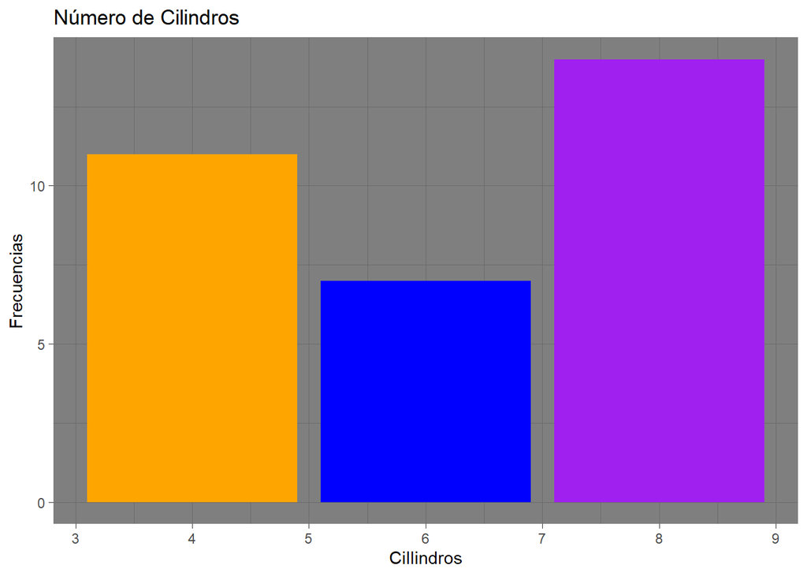

```r
colores <- c("orange","blue","purple")

ggplot(mtcars,aes(cyl)) + geom_bar(fill=colores) + labs(x="Cillindros",y="Frecuencias",title="Número de Cilindros") + theme_dark()
```

## 0.4 Bar Chart - Lattice

**Lattice**(Sarkar, 2008) es un paquete del lenguaje de programación R, que nos permite crear gráficos estadísticos de muy buena calidad, nos enfocaremos en la variable cyl (**cilindros**) para la creación del gráfico estadístico respectivo, como se muestra a continuación.

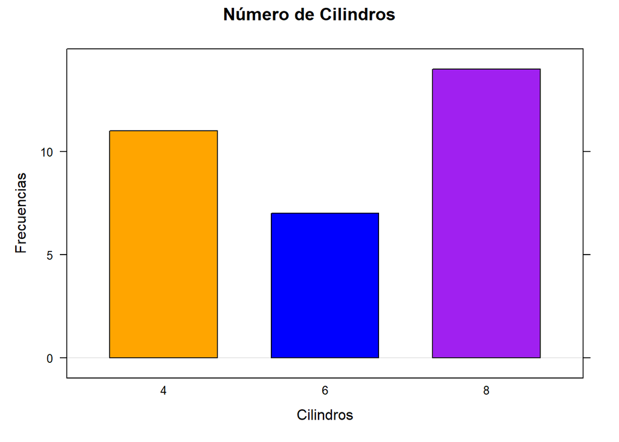

```r
x <- table(mtcars$cyl)

barchart(x,xlab="Cilindros",ylab="Frecuencias",main="Número de Cilindros",col=colores,horizontal=FALSE)
```

## 0.5 SQL - MySQL

```sql
select Code,Country_name,Continente from country;
```

Displaying records 1 - 20

| Code | Country_name | Continente |
| --- | --- | --- |
| ABW | Aruba | North America |
| AFG | Afghanistan | Asia |
| AGO | Angola | Africa |
| AIA | Anguilla | North America |
| ALB | Albania | Europe |
| AND | Andorra | Europe |
| ANT | Netherlands Antilles | North America |
| ARE | United Arab Emirates | Asia |
| ARG | Argentina | South America |
| ARM | Armenia | Asia |
| ASM | American Samoa | Oceania |
| ATA | Antarctica | Antarctica |
| ATF | French Southern territories | Antarctica |
| ATG | Antigua and Barbuda | North America |
| AUS | Australia | Oceania |
| AUT | Austria | Europe |
| AZE | Azerbaijan | Asia |
| BDI | Burundi | Africa |
| BEL | Belgium | Europe |
| BEN | Benin | Africa |

## 0.6 mtcars - cyl & gear

A continuación, mostramos como unir dos diagramas de barras (**Bar Charts**) en un solo gráfico, tomando como base el data set **mtcars**, así como sus variables **cyl** (cilindros) y **gear** (engranajes).

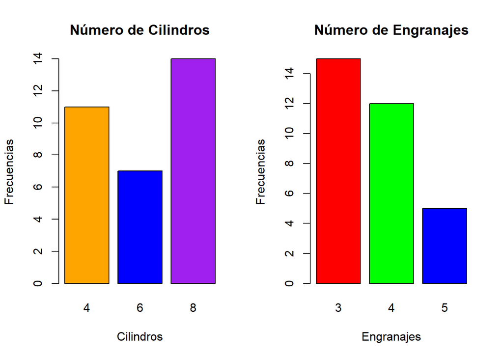

```r
y <- table(mtcars$gear)

par(mfrow=c(1,2))

barplot(x,xlab="Cilindros",ylab="Frecuencias",main="Número de Cilindros",col=colores)

barplot(y,xlab="Engranajes",ylab="Frecuencias",main="Número de Engranajes",col=rainbow(3))
```

## 0.7 Bar Charts - Matplotlib

**Matplotlib**(Hunter, 2007) es una librería del lenguaje de programación Python, que nos permite crear gráficos estadísticos de gran calidad, **RMarkdown**(Allaire et al., 2022) nos permite trabajar con otros lenguajes de programación tales como **C++, SQL, Julia**, entre muchos otros; a continuación mostramos un diagrama de barras (**Bar Chart**) creado con Matplotlib.

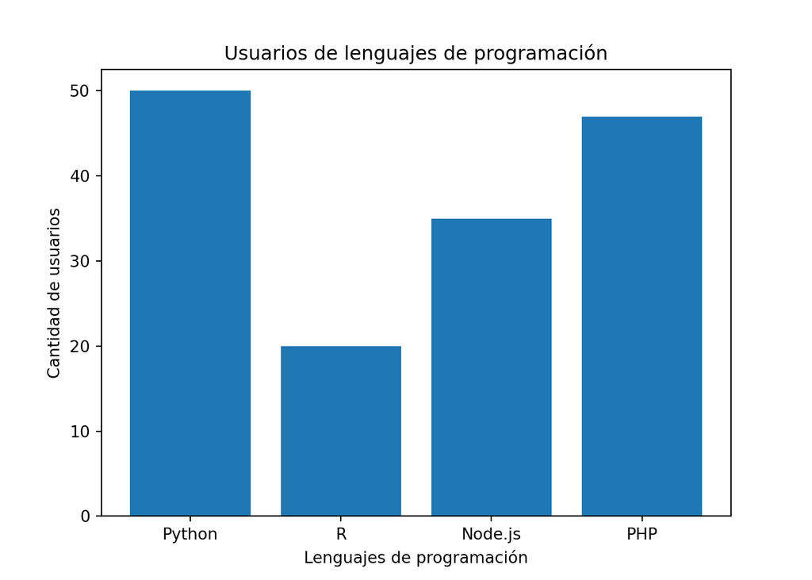

```python
eje_x = ['Python', 'R', 'Node.js', 'PHP']


eje_y = [50,20,35,47]


plt.bar(eje_x, eje_y)

plt.ylabel('Cantidad de usuarios')


plt.xlabel('Lenguajes de programación')


plt.title('Usuarios de lenguajes de programación')


plt.show()
```

## 0.8 YouTube - Tutorial

Compartimos el siguiente tutorial tomado de la plataforma **YouTube** que muestra como crear diagramas de barras (**Bar Charts**) haciendo uso de la función `barplot()` y el paquete **ggplot2** del lenguaje de programación R;utilizaremos el paquete **vembedr**(Lyttle, 2021) para añadir un vídeo de YouTube a nuestro documento RMarkdown.

```r
embed_url("https://www.youtube.com/watch?v=EkxRj02iaLk&t=6s") %>%
  use_align("center")
```

[video not shown]

**Inicio Documento**

## Referencias Bibliográficas

Allaire, J., Xie, Y., McPherson, J., Luraschi, J., Ushey, K., Atkins, A., Wickham, H., Cheng, J., Chang, W., & Iannone, R. (2022). *rmarkdown: Dynamic Documents for R*. https://github.com/rstudio/rmarkdown

Hunter, J. D. (2007). Matplotlib: A 2D graphics environment. *Computing in Science & Engineering*, *9*(3), 90-95. https://doi.org/10.1109/MCSE.2007.55

Lyttle, I. (2021). *vembedr: Embed Video in HTML*. https://CRAN.R-project.org/package=vembedr

R Core Team. (2022). *R: A Language and Environment for Statistical Computing*. R Foundation for Statistical Computing. https://www.R-project.org/

Santana Sepúlveda, S., Mateos Farfán, E., et al. (2014). *El arte de programar en R: un lenguaje para la estadı́stica*. México: Instituto Mexicano de Tecnologı́a del Agua. UNESCO. Comité Nacional ….

Sarkar, D. (2008). *Lattice: Multivariate Data Visualization with R*. Springer. http://lmdvr.r-forge.r-project.org

Van Rossum, G., & Drake Jr, F. L. (1995). *Python reference manual*. Centrum voor Wiskunde en Informatica Amsterdam.

Wickham, H. (2016). *ggplot2: Elegant Graphics for Data Analysis*. Springer-Verlag New York. https://ggplot2.tidyverse.org

[^1]: RMarkdown es un paquete del lenguaje de programación R,que nos permite crear documentos científicos y técnicos para luego convertirlos a formatos tales como HTML,PDF, Microsoft Word entre otros.